# Week 7 Milestone Factors

Author

Dairy Cow Foot Doc

Published

December 15, 2025

# Report for Herd 2108e

- This report shows data from the past year from **2024-10-05 to 2025-10-05**.

## Objective

Your objective is to recreate the solution data by doing the following with the raw_data table.

- id_animal is a combination of source_file_path, ID, BDAT
- Herd is extracted from the source_file_path extract the protocol data from the text fields
- protocols1 and remark1 contain the first set of character strings before a non character string is found.
- convert the exported data fields to real dates

## Your Code Creation

### Create DIM Categories

Then on the new data table.

- Create a dim_cat that splits DIM into 6 categories.
- Order this variable in the correct order so if you were to graph it the categories would make sense and would not be in numerical or alphabetical order

```r
# put your DIM category code here
```

### Import Function

Then import this function from Github This function will create new variables for LAME and TRIM remarks in your data set that now has clean protocol and remark fields and an associated dim_cat variable. The function is called fxn_code_lesions() and it takes 3 input variables event_var, protocol_var, remark_var.

```r
raw_url <- "https://raw.githubusercontent.com/Dairy-Cow-Foot-Doc/os_functions/main/fxn_code_lesions.R"

source(raw_url)
```

### Create New Variables

Then use this function to create new variables for the lesions in your data set.

```r
# put your code for recoding the variables here
```

## Plot Data

- Summarize this new data for the past 12 months to create a graph that looks similar to this

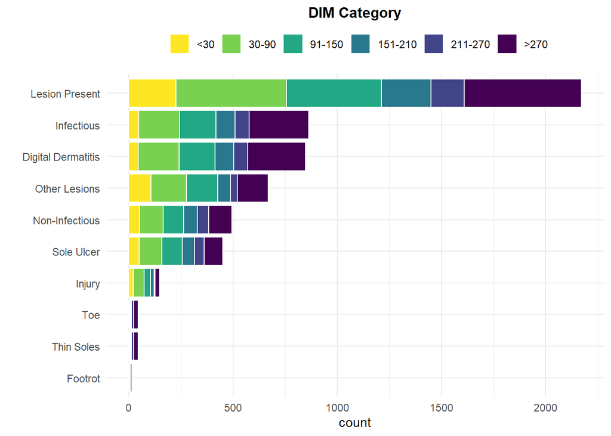

Figure 1: Lameness Lesions by DIM Category

```r
# this might be helpful for your grap labels.

all_lesions <- c("dd", "footrot", 'wld', "sole_ulcer","injury",
                             "cork", "other", "hemorrhage",
                             "sole_fracture", "toe_ulcer", "thin",
                             "inf", "noninf", "toe", "axial", "lesion")


# you can use this with the !!! we discussed last week to relabels the factor
  lesion_labels <- c(
    "Digital Dermatitis" = "dd",
    "Footrot" = "footrot",
    "White Line Disease" = "wld",
     "Sole Ulcer" = "sole_ulcer",
    "Hemorrhage" = "hemorrhage",
    "Sole Fracture" = "sole_fracture",
     "Toe Ulcer" = "toe_ulcer",
     "Thin Soles" = "thin",
     "Corkscrew Claw" = "cork",
     "Injury" = "injury",
     "Infectious" = "inf",
     "Non-Infectious" = "noninf",
     "Toe" = "toe",
     "Axial" = "axial",
     "Other Lesions" = "other",
     "Lesion Present" = "lesion"
  )



plot <- lame_dim_graph()

plot
```

# Extension

For this week extension continue to create standard things would want to report

Ideas (or hints for next week include)

start doing math with dates so we can calculate time to event data (cull/repeat)